# Part I - Prosper Loan Data Exploration

## Introduction

> This dataset contains 113,937 loans with 81 variables on each loan. It explores the relationship between certain features including loan amount, loan status, borrower income, etc.

## Preliminary Wrangling

```python
# import all required packages and set plots to be embedded inline
import numpy as np
import pandas as pd
import matplotlib.pyplot as plt
import seaborn as sns

%matplotlib inline
```

```python
## load in the dataset into a pandas dataframe
loan_df= pd.read_csv('prosperLoanData.csv')
loan_df.head()
```

|  | ListingKey | ListingNumber | ListingCreationDate | CreditGrade | Term | LoanStatus | ClosedDate | BorrowerAPR | BorrowerRate | LenderYield | ... | LP_ServiceFees | LP_CollectionFees | LP_GrossPrincipalLoss | LP_NetPrincipalLoss | LP_NonPrincipalRecoverypayments | PercentFunded | Recommendations | InvestmentFromFriendsCount | InvestmentFromFriendsAmount | Investors |
| --- | --- | --- | --- | --- | --- | --- | --- | --- | --- | --- | --- | --- | --- | --- | --- | --- | --- | --- | --- | --- | --- |
| 0 | 1021339766868145413AB3B | 193129 | 2007-08-26 19:09:29.263000000 | C | 36 | Completed | 2009-08-14 00:00:00 | 0.16516 | 0.1580 | 0.1380 | ... | -133.18 | 0.0 | 0.0 | 0.0 | 0.0 | 1.0 | 0 | 0 | 0.0 | 258 |
| 1 | 10273602499503308B223C1 | 1209647 | 2014-02-27 08:28:07.900000000 | NaN | 36 | Current | NaN | 0.12016 | 0.0920 | 0.0820 | ... | 0.00 | 0.0 | 0.0 | 0.0 | 0.0 | 1.0 | 0 | 0 | 0.0 | 1 |
| 2 | 0EE9337825851032864889A | 81716 | 2007-01-05 15:00:47.090000000 | HR | 36 | Completed | 2009-12-17 00:00:00 | 0.28269 | 0.2750 | 0.2400 | ... | -24.20 | 0.0 | 0.0 | 0.0 | 0.0 | 1.0 | 0 | 0 | 0.0 | 41 |
| 3 | 0EF5356002482715299901A | 658116 | 2012-10-22 11:02:35.010000000 | NaN | 36 | Current | NaN | 0.12528 | 0.0974 | 0.0874 | ... | -108.01 | 0.0 | 0.0 | 0.0 | 0.0 | 1.0 | 0 | 0 | 0.0 | 158 |
| 4 | 0F023589499656230C5E3E2 | 909464 | 2013-09-14 18:38:39.097000000 | NaN | 36 | Current | NaN | 0.24614 | 0.2085 | 0.1985 | ... | -60.27 | 0.0 | 0.0 | 0.0 | 0.0 | 1.0 | 0 | 0 | 0.0 | 20 |

5 rows × 81 columns

In the preliminary wrangling phase, we have an overview of the shape, statistics and datatypes of the dataset. Certain data types of specific columns in the dataset are changed for a seamless exploration.

```python
loan_df.shape
```

```
(113937, 81)
```

```python
# change the following data types to datetime
loan_df[['ListingCreationDate', 'ClosedDate', 'FirstRecordedCreditLine', 'LoanOriginationDate']]=loan_df[['ListingCreationDate', 'ClosedDate', 'FirstRecordedCreditLine','LoanOriginationDate']].apply(pd.to_datetime)
```

```python
# extract year from listing creation date into a separate column
loan_df['Year'] = loan_df['ListingCreationDate'].dt.year
```

```python
# extract quarter from listing creation date into a separate column
loan_df['Quarter'] = loan_df['ListingCreationDate'].dt.quarter
```

```python
#change the following data types to category
loan_df[['LoanStatus', 'ProsperRating (numeric)', 'ProsperRating (Alpha)', 'ProsperScore', 'ListingCategory (numeric)', 'LoanOriginationQuarter', 'IncomeRange','Quarter']]= loan_df[['LoanStatus','ProsperRating (numeric)', 'ProsperRating (Alpha)', 'ProsperScore','ListingCategory (numeric)', 'LoanOriginationQuarter', 'IncomeRange', 'Quarter']].apply(lambda x: x.astype('category'))
```

```python
loan_df.info()
```

```
<class 'pandas.core.frame.DataFrame'>
RangeIndex: 113937 entries, 0 to 113936
Data columns (total 83 columns):
 #   Column                               Non-Null Count   Dtype
---  ------                               --------------   -----
 0   ListingKey                           113937 non-null  object
 1   ListingNumber                        113937 non-null  int64
 2   ListingCreationDate                  113937 non-null  datetime64[ns]
 3   CreditGrade                          28953 non-null   object
 4   Term                                 113937 non-null  int64
 5   LoanStatus                           113937 non-null  category
 6   ClosedDate                           55089 non-null   datetime64[ns]
 7   BorrowerAPR                          113912 non-null  float64
 8   BorrowerRate                         113937 non-null  float64
 9   LenderYield                          113937 non-null  float64
```

[output cut: 75 more lines]

```python
 #drop duplicate rows
loan_df.drop_duplicates (subset=None, keep='first', inplace=False)
```

|  | ListingKey | ListingNumber | ListingCreationDate | CreditGrade | Term | LoanStatus | ClosedDate | BorrowerAPR | BorrowerRate | LenderYield | ... | LP_GrossPrincipalLoss | LP_NetPrincipalLoss | LP_NonPrincipalRecoverypayments | PercentFunded | Recommendations | InvestmentFromFriendsCount | InvestmentFromFriendsAmount | Investors | Year | Quarter |
| --- | --- | --- | --- | --- | --- | --- | --- | --- | --- | --- | --- | --- | --- | --- | --- | --- | --- | --- | --- | --- | --- |
| 0 | 1021339766868145413AB3B | 193129 | 2007-08-26 19:09:29.263 | C | 36 | Completed | 2009-08-14 | 0.16516 | 0.1580 | 0.1380 | ... | 0.0 | 0.0 | 0.0 | 1.0 | 0 | 0 | 0.0 | 258 | 2007 | 3 |
| 1 | 10273602499503308B223C1 | 1209647 | 2014-02-27 08:28:07.900 | NaN | 36 | Current | NaT | 0.12016 | 0.0920 | 0.0820 | ... | 0.0 | 0.0 | 0.0 | 1.0 | 0 | 0 | 0.0 | 1 | 2014 | 1 |
| 2 | 0EE9337825851032864889A | 81716 | 2007-01-05 15:00:47.090 | HR | 36 | Completed | 2009-12-17 | 0.28269 | 0.2750 | 0.2400 | ... | 0.0 | 0.0 | 0.0 | 1.0 | 0 | 0 | 0.0 | 41 | 2007 | 1 |
| 3 | 0EF5356002482715299901A | 658116 | 2012-10-22 11:02:35.010 | NaN | 36 | Current | NaT | 0.12528 | 0.0974 | 0.0874 | ... | 0.0 | 0.0 | 0.0 | 1.0 | 0 | 0 | 0.0 | 158 | 2012 | 4 |
| 4 | 0F023589499656230C5E3E2 | 909464 | 2013-09-14 18:38:39.097 | NaN | 36 | Current | NaT | 0.24614 | 0.2085 | 0.1985 | ... | 0.0 | 0.0 | 0.0 | 1.0 | 0 | 0 | 0.0 | 20 | 2013 | 3 |
| ... | ... | ... | ... | ... | ... | ... | ... | ... | ... | ... | ... | ... | ... | ... | ... | ... | ... | ... | ... | ... | ... |
| 113932 | E6D9357655724827169606C | 753087 | 2013-04-14 05:55:02.663 | NaN | 36 | Current | NaT | 0.22354 | 0.1864 | 0.1764 | ... | 0.0 | 0.0 | 0.0 | 1.0 | 0 | 0 | 0.0 | 1 | 2013 | 2 |
| 113933 | E6DB353036033497292EE43 | 537216 | 2011-11-03 20:42:55.333 | NaN | 36 | FinalPaymentInProgress | NaT | 0.13220 | 0.1110 | 0.1010 | ... | 0.0 | 0.0 | 0.0 | 1.0 | 0 | 0 | 0.0 | 22 | 2011 | 4 |
| 113934 | E6E13596170052029692BB1 | 1069178 | 2013-12-13 05:49:12.703 | NaN | 60 | Current | NaT | 0.23984 | 0.2150 | 0.2050 | ... | 0.0 | 0.0 | 0.0 | 1.0 | 0 | 0 | 0.0 | 119 | 2013 | 4 |
| 113935 | E6EB3531504622671970D9E | 539056 | 2011-11-14 13:18:26.597 | NaN | 60 | Completed | 2013-08-13 | 0.28408 | 0.2605 | 0.2505 | ... | 0.0 | 0.0 | 0.0 | 1.0 | 0 | 0 | 0.0 | 274 | 2011 | 4 |
| 113936 | E6ED3600409833199F711B7 | 1140093 | 2014-01-15 09:27:37.657 | NaN | 36 | Current | NaT | 0.13189 | 0.1039 | 0.0939 | ... | 0.0 | 0.0 | 0.0 | 1.0 | 0 | 0 | 0.0 | 1 | 2014 | 1 |

113937 rows × 83 columns

```python
loan_df.describe()
```

|  | ListingNumber | Term | BorrowerAPR | BorrowerRate | LenderYield | EstimatedEffectiveYield | EstimatedLoss | EstimatedReturn | EmploymentStatusDuration | CreditScoreRangeLower | ... | LP_CollectionFees | LP_GrossPrincipalLoss | LP_NetPrincipalLoss | LP_NonPrincipalRecoverypayments | PercentFunded | Recommendations | InvestmentFromFriendsCount | InvestmentFromFriendsAmount | Investors | Year |
| --- | --- | --- | --- | --- | --- | --- | --- | --- | --- | --- | --- | --- | --- | --- | --- | --- | --- | --- | --- | --- | --- |
| count | 1.139370e+05 | 113937.000000 | 113912.000000 | 113937.000000 | 113937.000000 | 84853.000000 | 84853.000000 | 84853.000000 | 106312.000000 | 113346.000000 | ... | 113937.000000 | 113937.000000 | 113937.000000 | 113937.000000 | 113937.000000 | 113937.000000 | 113937.000000 | 113937.000000 | 113937.000000 | 113937.000000 |
| mean | 6.278857e+05 | 40.830248 | 0.218828 | 0.192764 | 0.182701 | 0.168661 | 0.080306 | 0.096068 | 96.071582 | 685.567731 | ... | -14.242698 | 700.446342 | 681.420499 | 25.142686 | 0.998584 | 0.048027 | 0.023460 | 16.550751 | 80.475228 | 2011.012481 |
| std | 3.280762e+05 | 10.436212 | 0.080364 | 0.074818 | 0.074516 | 0.068467 | 0.046764 | 0.030403 | 94.480605 | 66.458275 | ... | 109.232758 | 2388.513831 | 2357.167068 | 275.657937 | 0.017919 | 0.332353 | 0.232412 | 294.545422 | 103.239020 | 2.504353 |
| min | 4.000000e+00 | 12.000000 | 0.006530 | 0.000000 | -0.010000 | -0.182700 | 0.004900 | -0.182700 | 0.000000 | 0.000000 | ... | -9274.750000 | -94.200000 | -954.550000 | 0.000000 | 0.700000 | 0.000000 | 0.000000 | 0.000000 | 1.000000 | 2005.000000 |
| 25% | 4.009190e+05 | 36.000000 | 0.156290 | 0.134000 | 0.124200 | 0.115670 | 0.042400 | 0.074080 | 26.000000 | 660.000000 | ... | 0.000000 | 0.000000 | 0.000000 | 0.000000 | 1.000000 | 0.000000 | 0.000000 | 0.000000 | 2.000000 | 2008.000000 |
| 50% | 6.005540e+05 | 36.000000 | 0.209760 | 0.184000 | 0.173000 | 0.161500 | 0.072400 | 0.091700 | 67.000000 | 680.000000 | ... | 0.000000 | 0.000000 | 0.000000 | 0.000000 | 1.000000 | 0.000000 | 0.000000 | 0.000000 | 44.000000 | 2012.000000 |
| 75% | 8.926340e+05 | 36.000000 | 0.283810 | 0.250000 | 0.240000 | 0.224300 | 0.112000 | 0.116600 | 137.000000 | 720.000000 | ... | 0.000000 | 0.000000 | 0.000000 | 0.000000 | 1.000000 | 0.000000 | 0.000000 | 0.000000 | 115.000000 | 2013.000000 |
| max | 1.255725e+06 | 60.000000 | 0.512290 | 0.497500 | 0.492500 | 0.319900 | 0.366000 | 0.283700 | 755.000000 | 880.000000 | ... | 0.000000 | 25000.000000 | 25000.000000 | 21117.900000 | 1.012500 | 39.000000 | 33.000000 | 25000.000000 | 1189.000000 | 2014.000000 |

8 rows × 59 columns

### What is the structure of your dataset?

> This dataset contains 113,937 loans with 81 variables on each loan. Most variables are numeric in nature, but some including the variables prosper score, listing category, income range, loan status, prosper ratings, loan origination quarter are categorical.

### What is/are the main feature(s) of interest in your dataset?

> This dataset explores the features that play a significant role in the loan amount disbursed .

### What features in the dataset do you think will help support your investigation into your feature(s) of interest?

> Features that support this investigation include;
> - Loan original amount
> - Loan status
> - Borrower's APR
> - Lender Yield
> - Year
> - Quarter
> - Listing category
> - Prosper score
> - Income range
> - Employment status
> - Home ownership
> - Total prosper loans
> - Outstanding principal
> - Borrowed principal
> - On-time prosper payments

## Univariate Exploration

We begin by creating a visual of the loan status;

## What is the frequency of each loan status?

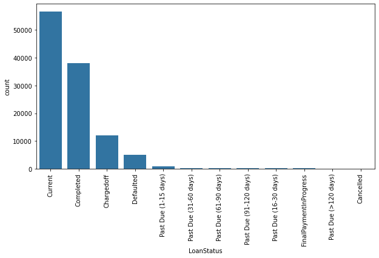

```python
plt.figure(figsize = [10,5])

base_color = sns.color_palette()[0]

freq = loan_df['LoanStatus'].value_counts()

# Get the indexes of the Series
gen_order = freq.index

# Plot the bar chart in decreasing order of the frequency of the `LoanStatus'
sns.countplot(data=loan_df, x='LoanStatus', color= base_color, order = gen_order)

plt.xticks(rotation=90);
```

Next we examine the factors that possibly affect the above loan status. We begin with the borrower APR (Annual Percentage Rate) which is the percentage of principal to be paid each year. The distribution of the APR is shown below.

To gauge the appropriate bin limits for this plot, we use descriptive statistics as shown below;

```python
loan_df['BorrowerAPR'].describe()
```

```
count    113912.000000
mean          0.218828
std           0.080364
min           0.006530
25%           0.156290
50%           0.209760
75%           0.283810
max           0.512290
Name: BorrowerAPR, dtype: float64
```

## What is the distribution of the Borrower APR?

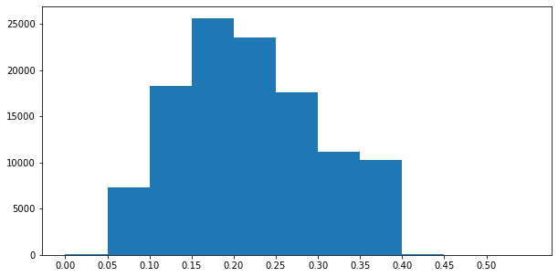

```python
plt.figure(figsize = [10, 5])
# Create bins with step-size 5
bins = np.arange(0, loan_df['BorrowerAPR'].max()+0.05,0.05 )
plt.hist(data = loan_df, x = 'BorrowerAPR', bins = bins);
plt.xticks(np.arange(0, 0.5+0.05, 0.05));
```

From the above plot, we find that the borrower APR with the most count is between 0.15-0.20. This number steadily drops after APR of 0.20.

Next, we examine the listing category to know which one is most frequent.

## Which listing category is most popular?

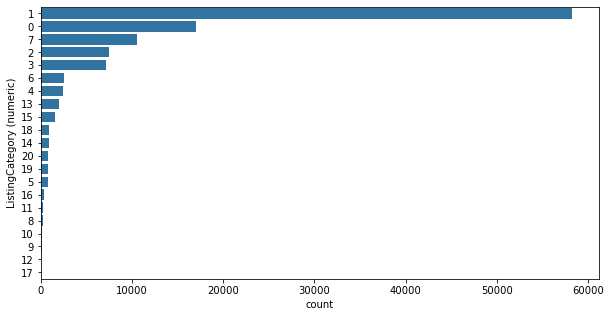

```python
# Plot the listing category on a Horizontal bar chart
#Listing category is represented by: 0 - Not Available, 1 - Debt Consolidation, 2 - Home Improvement, 3 - Business, 4 - Personal Loan, 5 - Student Use, 6 - Auto, 7- Other, 8 - Baby&Adoption, 9 - Boat, 10 - Cosmetic Procedure, 11 - Engagement Ring, 12 - Green Loans, 13 - Household Expenses, 14 - Large Purchases, 15 - Medical/Dental, 16 - Motorcycle, 17 - RV, 18 - Taxes, 19 - Vacation, 20 - Wedding Loans
plt.figure(figsize = [10,5])
type_order = loan_df['ListingCategory (numeric)'].value_counts().index
sns.countplot(data=loan_df, y='ListingCategory (numeric)', color=base_color, order=type_order)
```

The chart above is plotted in order of frequency beginning with the most frequent. It shows that loan was most collected for debt consolidation, represented by 1 followed by 0 which means the use is not specified. Other categories which loan was most collected for include, home improvement(2), business (3).

We will now look at the income range of the loan collectors.

## What is the income range of the loan collectors?

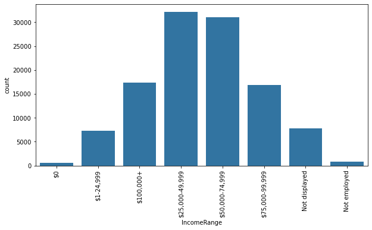

```python
plt.figure(figsize = [10,5])
sns.countplot(data=loan_df, x='IncomeRange', color=base_color);

# Use xticks to rotate the category labels counter-clockwise
plt.xticks(rotation=90);
```

## What is the count of loan collectors that are homeowners?

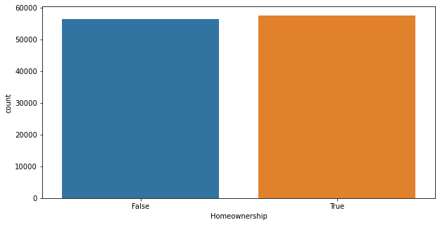

```python
# plot count plot for the homeowner column
plt.figure(figsize=[10,5])
sns.countplot(loan_df.IsBorrowerHomeowner)
plt.xlabel('Homeownership')
```

The count of homeowners and non-homeowners are almost equal. But homeowners have a higher count

## What is the distribution of loan amount?

```python
loan_df['LoanOriginalAmount'].describe()
```

```
count    113937.00000
mean       8337.01385
std        6245.80058
min        1000.00000
25%        4000.00000
50%        6500.00000
75%       12000.00000
max       35000.00000
Name: LoanOriginalAmount, dtype: float64
```

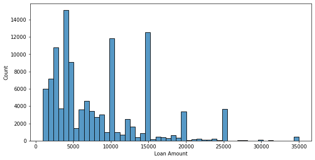

```python
plt.figure(figsize = [10,5])
bins = np.arange(1000, loan_df['LoanOriginalAmount'].max()+ 680, 680)
sns.histplot(loan_df['LoanOriginalAmount'], bins = bins);
plt.xlabel('Loan Amount')
```

From the distribution above, we see spikes between 2500- 5000. Subsequent spikes are seen at 10,000 and 15,000. This shows that loans are usually collected in round figures. We also note from the tallest spike that the most number of loan collected was 4000.

## What is the distribution of Prosper Score?

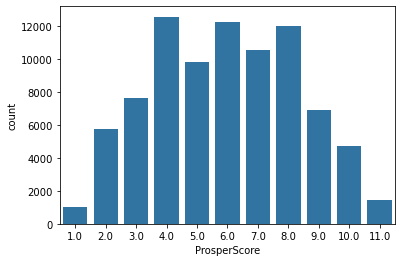

```python
#Prosper score is a custom risk score built using historical Prosper data. The score ranges from 1-10, with 10 being the best, or lowest risk score.
sns.countplot(data=loan_df, x='ProsperScore', color=base_color);
```

The prosper score shows the most count at 4.0, 6.0 and 8.0 This means that loans were collected for mostly medium-risk ventures.

## What is the distribution of the Outstanding Principal?

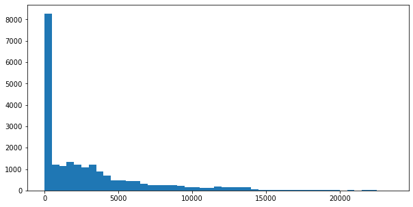

```python
plt.figure(figsize = [10,5])
bins = np.arange(0, loan_df['ProsperPrincipalOutstanding'].max()+ 500, 500)
plt.hist(loan_df['ProsperPrincipalOutstanding'], bins = bins);
```

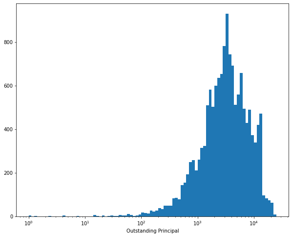

```python
# there's a long tail in the distribution, so let's put it on a log scale instead
log_binsize = 0.050
bins = 10 ** np.arange(0, np.log10(loan_df['ProsperPrincipalOutstanding'].max())+log_binsize, log_binsize)

plt.figure(figsize=[10, 8])
plt.hist(data = loan_df, x = 'ProsperPrincipalOutstanding', bins = bins)
plt.xscale('log')
plt.xlabel('Outstanding Principal')
plt.show()
```

Outstanding principal has a long tail distribution with most of the amount left to pay on the low end. When plotted with a log scale, the distribution is multimodal and tilted to the right indicating that there might be outliers on the left.

### Discuss the distribution(s) of your variable(s) of interest. Were there any unusual points? Did you need to perform any transformations?

> The variables of interest are loan status and loan amount. The distribution of loan amount showed a number of peaks between 2500-5000. At 5000, there was a dip and another peak at 10000.

### Of the features you investigated, were there any unusual distributions? Did you perform any operations on the data to tidy, adjust, or change the form of the data? If so, why did you do this?

## Bivariate Exploration

This section starts off with an investigation of the relationship between the two main features of interest - loan amount and loan status.

## What is the relationship between loan amount and loan status?

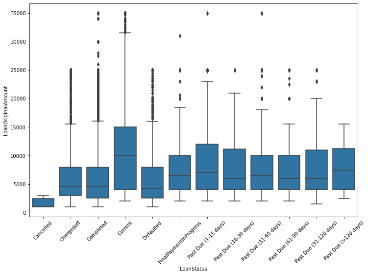

```python
plt.figure(figsize=[12,8])
sns.boxplot(data=loan_df, x='LoanStatus', y='LoanOriginalAmount', color=base_color)
plt.xticks(rotation=45);
```

The loan status with the highest loan amount is "current" with a median loan amount of 10,000 and a maximum length at 32,000. The loan status with the least amount is "cancelled". This means that a high amount of loans are yet to meet their deadline.

## How often were loans given out to high risk ventures?

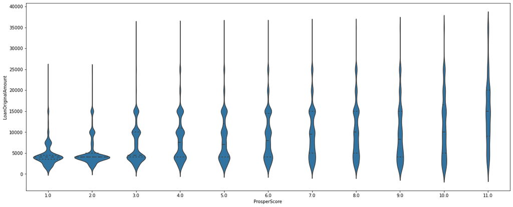

```python
#The score ranges from 1-10, with 10 being the best, or lowest risk score.
plt.figure(figsize = [20,8])
sns.violinplot(data=loan_df, x='ProsperScore', y='LoanOriginalAmount', color=base_color, inner= 'quartile');
```

From the violin plot above, high risk prosper scores are shown to have smaller loan amounts (shown by the wide curves) as opposed to low risk prosper scores although there are a number of outliers. The low risk prosper scores have the smallest distribution of loan applications.

## Do people with a high income range get more loans?

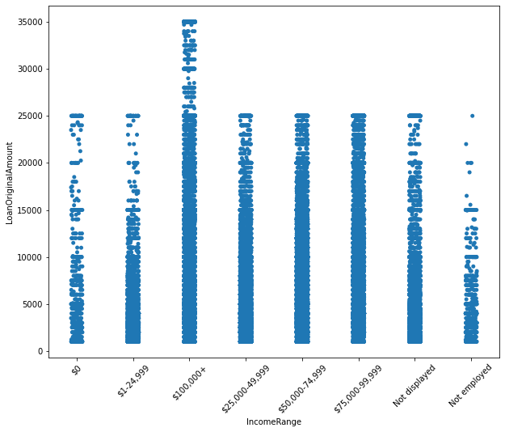

```python
plt.figure(figsize = [10,8])
sns.stripplot(data = loan_df, x = 'IncomeRange', y = 'LoanOriginalAmount', color = base_color)
plt.xticks(rotation=45);
```

The stripplot above shows that people who earn 100k and above get the most loans while people who are not employed get the least with exception to a few outliers. It's safe to say that more loan is given to borrowers with high income range.

## What is the relationship between the loan amount and lender yield?

```python
loan_df ['LenderYield'].describe()
```

```
count    113937.000000
mean          0.182701
std           0.074516
min          -0.010000
25%           0.124200
50%           0.173000
75%           0.240000
max           0.492500
Name: LenderYield, dtype: float64
```

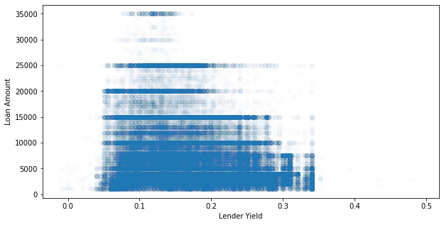

```python
plt.figure(figsize=[10,5])
plt.scatter(data = loan_df, x = 'LenderYield', y = 'LoanOriginalAmount', alpha = 0.01)

plt.xlabel('Lender Yield')
plt.ylabel('Loan Amount')
```

The lender yield has a high distribution between 0.1 and 0.3. With loan amounts between 5000 and 10000, we notice a few outliers extend to 0.35. We also notice that lender yield reduces with an increase in loan amount which indicates a negative correlation between both variables.

## How does total loans change with loan amount?

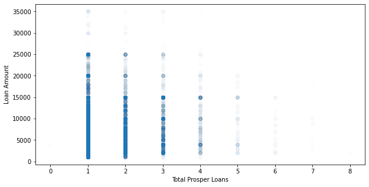

```python
plt.figure(figsize=[10,5])
plt.scatter(data = loan_df, x = 'TotalProsperLoans', y = 'LoanOriginalAmount', alpha = 0.01)

plt.xlabel('Total Prosper Loans')
plt.ylabel('Loan Amount')
```

## Are homeowners most likely to complete loan payments?

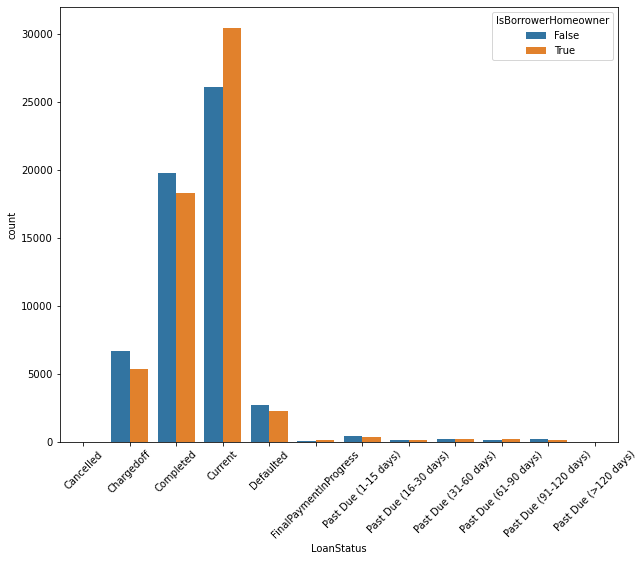

```python
plt.figure(figsize=[10,8])
sns.countplot(data = loan_df, x = 'LoanStatus', hue = 'IsBorrowerHomeowner')
plt.xticks(rotation=45);
```

The chart above does not show a significant difference in the loan status of homeowners and non-homeowners. It even appears that nonhomeowners are more likely to complete their loans as the count is higher.

## How does Loan amount change over time?

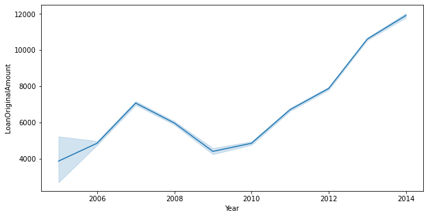

```python
fig = plt.figure(figsize = (10, 5))

# creating the line plot
sns.lineplot (x= 'Year', y='LoanOriginalAmount', data= loan_df)
```

The line chart above shows a steady increase in the amount of loans given out from 2006. In 2007, there is a dip which continues until 2009. After which there is a continuous increase. A high increase in loan amount is shown in 2013 which is indicative of an event that might have occurred.

## What is the relationship between borrowed principal and outstanding principal?

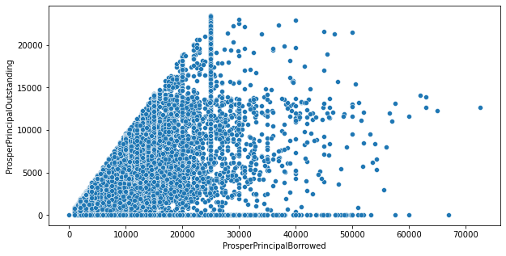

```python
plt.figure(figsize = (10, 5))
sns.scatterplot(loan_df.ProsperPrincipalBorrowed, loan_df.ProsperPrincipalOutstanding)
```

The plot above shows a postive correlation between outstanding principal and borrowed principal. At the beginning of the plot, we see a steady increase in the outstanding principal as borrowed principal increases. We also see a high population of the data between 0 and 20000 after which we see a decrease in population and increased incosistency.

## What is the distribution of borrower APR across Income Range?

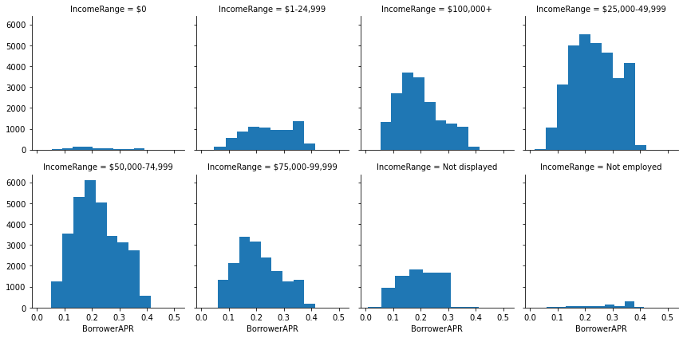

```python
# Plot the Seaborn's FacetGrid
g = sns.FacetGrid(data = loan_df, col = 'IncomeRange', col_wrap= 4)
g.map(plt.hist, 'BorrowerAPR')
```

The Facetgrid above shows the distribution of borrower APR across all income ranges. We notice that borrowers with income range of 50,000-74,999 have the most count and distribution of APR. Otherwise, the distribution of borrower APR across all income ranges were relatively the same.

## What listing category has the most distribution of loan amount?

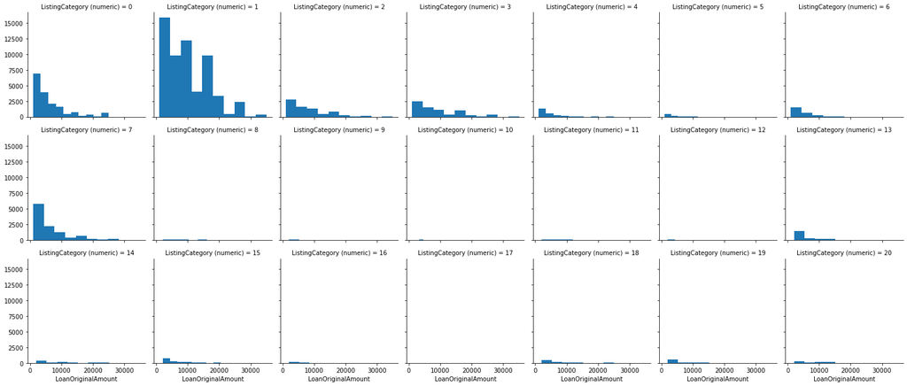

```python
# Plot the Seaborn's FacetGrid
g = sns.FacetGrid(data = loan_df, col = 'ListingCategory (numeric)', col_wrap= 7)
g.map(plt.hist, 'LoanOriginalAmount')
```

The listing category with the most count and loan amount distribution is debt consolidation.

## What is the likelihood of on time payments across prosper scores?

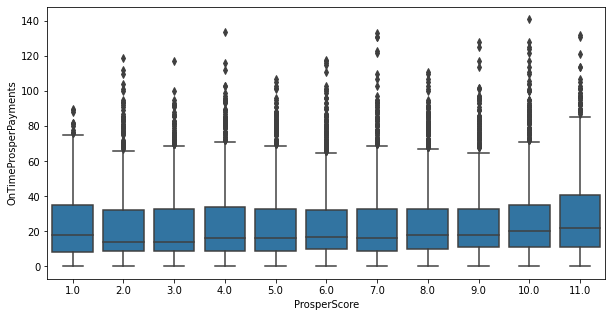

```python
plt.figure(figsize=[10,5])
sns.boxplot(data=loan_df, x='ProsperScore', y='OnTimeProsperPayments', color=base_color);
```

The prosper score with the most on-time payment is 11 with on-time payment of 80. This means that low-risk ventures are more likely to pay back loans on time.

## How does employment status affect the amount of loan given?

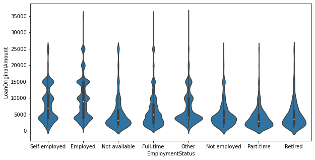

```python
plt.figure(figsize=[10,5])
sns.violinplot(data=loan_df, x='EmploymentStatus', y='LoanOriginalAmount', color=base_color);
```

The plot above shows more distribution across different loan amounts for the self-employed and employed status of employment. We also notice that people who are not employed, have part-time employment and are retired have more distribution in the 5000 loan amount region. The means that people who are employed are most likely to either apply for higher loan amounts or have loans of higher amounts given to them.

### Did you observe any interesting relationships between the other features (not the main feature(s) of interest)?

- The relationship between on-time payments and prosper score shows that low-risk ventures are more likely to pay back loans on time
- Borrowers with income range of 50,000-74,999 have the most count and distribution of APR
- There's a slight postive correlation between outstanding principal and borrowed principal

## What is the relationship between Borrower APR, Lender Yield and Loan Amount?

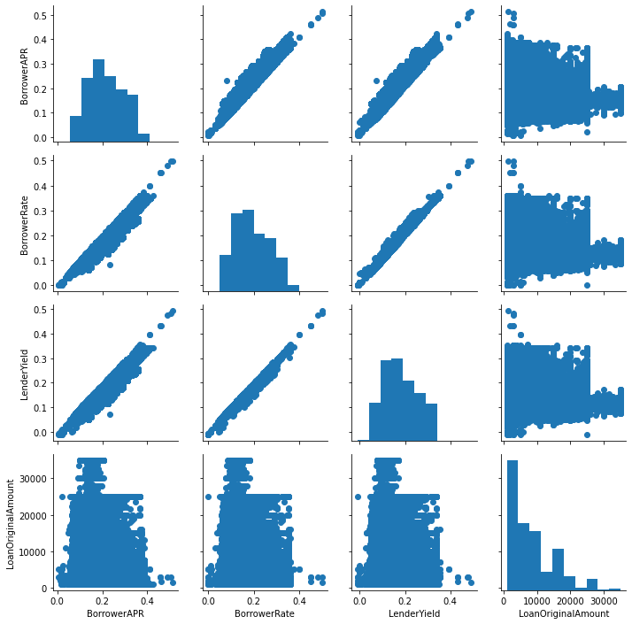

```python
figg = sns.PairGrid(data = loan_df, vars = ['BorrowerAPR', 'BorrowerRate', 'LenderYield', 'LoanOriginalAmount'])
figg.map_diag(plt.hist)
figg.map_offdiag(plt.scatter)
```

The pairgrid above shows a strong positive correlation between borrower APR and lender yield. Loan amount shows a negative correlation with both borrower APR and lender yield.

## What is the interaction between the numeric variables of interest?

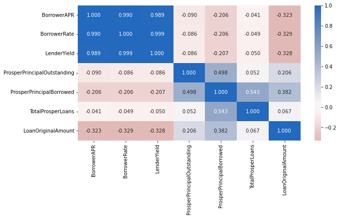

```python
#create list of numeric variables
numeric_vars = ['BorrowerAPR', 'BorrowerRate', 'LenderYield', 'ProsperPrincipalOutstanding', 'ProsperPrincipalBorrowed','TotalProsperLoans','LoanOriginalAmount']
# correlation plot with 1.0 as strongest correlation
plt.figure(figsize = [10, 5])
sns.heatmap(loan_df[numeric_vars].corr(), annot = True, fmt = '.3f',
           cmap = 'vlag_r', center = 0)
plt.show()
```

## How does loan amount change with every quarter in each year?

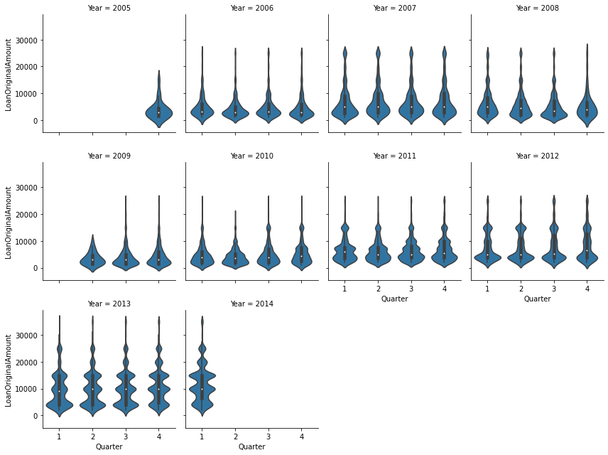

```python
plt.figure(figsize = [12, 5])
g = sns.FacetGrid(data = loan_df, col = 'Year', col_wrap= 4)
g.map(sns.violinplot, 'Quarter', 'LoanOriginalAmount')
```

As noted earlier in the visualisation of loan amount across time, loan amount increased exponentially in 2013. We see clearly now why that was. For every quarter in 2013, loan amount was as high as 30,000 including outliers hence its exponential increase. However, we also see that in the year 2014, loan amount was recorded only for the first quarter. The recorded loan amount was as high as 2013 quarterly records. This might indicate why there was no drop in the line plot in 2014.

### Talk about some of the relationships you observed in this part of the investigation. Were there features that strengthened each other in terms of looking at your feature(s) of interest?

> We see a strong positive correlation between borrower APR and lender yield and a negative correlation between loan amount and both borrower APR and lender yield from the pair grid and correlation heatmap above. The cause of this negative correlation is of interest.

### Were there any interesting or surprising interactions between features?

> Loan-seeking was at an all-time high in every quarter of 2013. A myriad of societal and economic factors could have played a role in this increase.

## Conclusions

Limitation: The dataset had only one quarter each for 2005 and 2014.